# Search for loci impactful to the %expanded phenotype

Part 1 - prep data

23 February 2022

```r
    # options
    knitr::opts_chunk$set(echo = TRUE)
    options(stringsAsFactors = FALSE, dplyr.summarise.inform = FALSE)

    # libraries
    library(tidyverse)
    library(cowplot)
    library(fs)
    library(qtl2)
    library(ggbeeswarm)
    library(ggforce)
    library(flextable)
    library(ggrepel)
    library(progress)
    devtools::load_all('../BXDstrs_package/BXDstrs')
    library(DT)
    library(ggh4x)
```

# 1 QTL region

```r
    ci_chr = '13'; ci_lo = 83.78112; ci_hi = 93.41913; ci_mid = 90.4
```

# 2 Load list of genes under QTL

```r
    # gene_ord = readRDS('../data/analysis_cache/eqtl_data.rds')$gene_ord
    gene_info = readRDS('../data/analysis_cache/embl_genes.rds')
```

# 3 Types of genes under QTL

Only consider protein coding ones (filter to these)

```r
    gene_info %>% count(gene_type) %>% arrange(desc(n))
```

| gene_type | n |
| --- | --- |
| processed_pseudogene | 34 |
| protein_coding | 30 |
| TEC | 10 |
| lincRNA | 9 |
| antisense | 7 |
| miRNA | 5 |
| sense_intronic | 2 |
| snoRNA | 2 |
| misc_RNA | 1 |
| processed_transcript | 1 |

[output cut: 2 more lines]

```r
    gene_info = gene_info %>% filter(gene_type == 'protein_coding')
```

# 4 Look up transcript coordinates

1. Roi: 13:83.8-93.4
2. Subset to only protein coding genes in the region

```r
    # connect to Ensembl
    e102 = biomaRt::useEnsembl(
        biomart = 'genes',
        host = 'http://nov2020.archive.ensembl.org',
        dataset = 'mmusculus_gene_ensembl',
        version = 102, verbose = FALSE)

    # # get gene descriptions
    # attr_to_get = c(
    #   # gene_id    = "ensembl_gene_id",
    #   gene_name  = "external_gene_name",
    #   gene_descr = "mgi_description",
    #   gene_type  = "gene_biotype",
    #   gene_pos = "start_position",
    #   gene_end = "end_position"
    # )
    # gene_info = biomaRt::getBM(
    #   attributes = attr_to_get,
    #   filters = c('chromosome_name', 'start', 'end'),
    #   values = c(list(ci_chr), list(ci_lo*1e6), list(ci_hi*1e6)),
    #   mart = e102) %>% as_tibble
    # gene_info = gene_info %>% rename(all_of(attr_to_get))

    # get transcript information
    attr_to_get = c(
        gene_id   = "ensembl_gene_id",
        gene_name = "external_gene_name",
        gene_type = "gene_biotype",
        chr       = "chromosome_name",
        tx_id     = "ensembl_transcript_id_version",
        tx_pos    = "transcript_start",
        tx_end    = "transcript_end",
        exon_id   = "ensembl_exon_id",
        exon_pos  = "exon_chrom_start",
        exon_end  = "exon_chrom_end",
        tx_type   = "transcript_biotype",
        cds_pos   = "genomic_coding_start",
        cds_end   = "genomic_coding_end",
        rank      = "rank"
    )
    tx_info = biomaRt::getBM(
        attributes = attr_to_get,
        # filters = c('chromosome_name', 'start', 'end'),
        # values = c(list(ci_chr), list(ci_lo*1e6), list(ci_hi*1e6)),
        filters = c('ensembl_gene_id'),
        values = c(list(gene_info %>% pull(gene_id))),
        mart = e102) %>% as_tibble

    # rename columns
    tx_info = tx_info %>% rename(all_of(attr_to_get))
    tx_info = tx_info %>% mutate(chr = str_c('chr', chr))

    # convert position
    tx_info = tx_info %>% mutate(across(matches('_(pos|end)$'), ~.x/1e6))

    # query TSL for each trascript
    attr_to_get = c(
        tx_id = "ensembl_transcript_id_version",
        tsl   = "transcript_tsl"
    )
    tx_supp = biomaRt::getBM(
        attributes = attr_to_get,
        filters = c('ensembl_transcript_id_version'),
        values = c(list(tx_info %>% distinct(tx_id) %>% pull(tx_id))),
        mart = e102) %>% as_tibble

    # format tsl column
    tx_supp = tx_supp %>%
        rename(all_of(attr_to_get)) %>%
        mutate(tsl = str_replace(tsl, ' \\(.*\\)$', '') %>% if_else(. == '', NA_character_, .)) %>%
        arrange(tsl) %>%
        mutate(tsl = fct_inorder(tsl))

    # join tx support levels back to tx_info
    tx_info = tx_info %>% left_join(tx_supp, by = 'tx_id')

    # checks
    if (0) {
        # levels
        # tx_info %>% pull(tsl) %>% levels

        # check how many transcripts per gene have a certain support level
        tx_info %>%
            distinct(gene_name, tx_id, tsl) %>%
            count(gene_name, tsl) %>%
            pivot_wider(id_cols = gene_name, names_from = tsl, values_from = n) %>%
            print(n = nrow(.))
    }

    # determine canonical transcript
    canon_lab = tx_info %>%
        mutate(tx_len = tx_end - tx_pos) %>%
        distinct(gene_name, tx_id, tx_len, tsl) %>%
        arrange(tsl, desc(tx_len)) %>%
        distinct(gene_name, .keep_all = TRUE) %>%
        mutate(is_canon = TRUE)

    # join canonical label
    tx_info = tx_info %>%
        left_join(canon_lab %>% select(gene_name, tx_id, is_canon), by = c('gene_name', 'tx_id')) %>%
        mutate(is_canon = replace_na(is_canon, FALSE))
```

# 5 Load VEP annotations

1. Ran VEP on all snp, str and sv variants in the region of interest
2. VEP EMBL references:
   - https://m.ensembl.org/info/genome/genebuild/biotypes.html
   - https://m.ensembl.org/info/genome/variation/prediction/predicted_data.html
3. Using SVs more accurate coordinates from REF/ALT realignment

```r
    # define columns
    vep_cols = c('Uploaded_variation', 'Location', 'Allele', 'Gene', 'Feature', 'Feature_type', 'Consequence', 'cDNA_position', 'CDS_position', 'Protein_position', 'Amino_acids', 'Codons', 'Existing_variation', 'IMPACT', 'DISTANCE', 'STRAND', 'FLAGS', 'VARIANT_CLASS', 'SYMBOL', 'SYMBOL_SOURCE', 'HGNC_ID', 'BIOTYPE', 'CANONICAL', 'MANE_SELECT', 'MANE_PLUS_CLINICAL', 'TSL', 'APPRIS', 'CCDS', 'ENSP', 'SWISSPROT', 'TREMBL', 'UNIPARC', 'UNIPROT_ISOFORM', 'GENE_PHENO', 'SIFT', 'EXON', 'INTRON', 'DOMAINS', 'miRNA', 'AF', 'AFR_AF', 'AMR_AF', 'EAS_AF', 'EUR_AF', 'SAS_AF', 'AA_AF', 'EA_AF', 'gnomAD_AF', 'gnomAD_AFR_AF', 'gnomAD_AMR_AF', 'gnomAD_ASJ_AF', 'gnomAD_EAS_AF', 'gnomAD_FIN_AF', 'gnomAD_NFE_AF', 'gnomAD_OTH_AF', 'gnomAD_SAS_AF', 'MAX_AF', 'MAX_AF_POPS', 'CLIN_SIG', 'SOMATIC', 'PHENO', 'PUBMED', 'MOTIF_NAME', 'MOTIF_POS', 'HIGH_INF_POS', 'MOTIF_SCORE_CHANGE', 'TRANSCRIPTION_FACTORS')

    # read VEP annotations for strs and snps/indels
    vep_annot = map(list(
        str = '../data/vep_annot/bxd_strs.annot.annot.tsv',
        # sv  = '../data/vep_annot/bxd_svs.annot.annot.tsv',
        sv  = '../data/sv_alig/vep/vep_out.tsv',
        snp = '../data/vep_annot/bxd_snp_indel.annot.annot.tsv'
    ), ~read_tsv(.x, comment = '#', col_names = vep_cols, col_types = cols(.default = 'c')))

    # now svs have a chr,pos,end,sv_type id
    vep_annot$sv = vep_annot$sv %>%
        separate('Uploaded_variation', c('chr', 'pos', 'end', 'sv_type'), sep = '_', convert = TRUE, fill = 'right') %>%
        unite('Uploaded_variation', c('chr', 'pos', 'end'))

    # save a raw version of vep_annot with extra info
    raw_vep_annot = vep_annot %>%
        map_df(~.x, .id = 'loc_type') %>%
        separate('Uploaded_variation', c('chr', 'pos', 'end'), sep = '_', convert = TRUE, fill = 'right')

    # combine
    col_keep = c('Uploaded_variation', 'Allele', 'Gene', 'Feature', 'Feature_type', 'Consequence',
                 'IMPACT', 'STRAND', 'VARIANT_CLASS', 'SYMBOL', 'BIOTYPE', 'Amino_acids', 'Existing_variation', 'sv_type')
    vep_annot = vep_annot %>% map_df(~.x %>% select(any_of(col_keep)), .id = 'loc_type')

    # split out the position and reference allele
    vep_annot = vep_annot %>%
        separate('Uploaded_variation', c('chr', 'pos', 'end'), sep = '_', convert = TRUE, fill = 'right')
    vep_annot = vep_annot %>% mutate(end = if_else(is.na(end), pos, end))

    # a little wider than what is needed for SVs, but this is ok
    # vep_annot %>% filter(loc_type == 'str') %>% select(chr, pos, end, sv_type)

    # fix missing values
    vep_annot = vep_annot %>%
        mutate(across(!c(loc_type, chr, pos, end, sv_type), ~if_else(.x == '-', NA_character_, .x)))

    # assign ordering to impacts
    vep_annot = vep_annot %>% mutate(IMPACT = fct_relevel(IMPACT, c('HIGH', 'MODERATE', 'LOW', 'MODIFIER')))

    # filter out loci which don't fit in window
    vep_annot = vep_annot %>%
        # filter(!(loc_type == 'sv' & (pos < ci_lo*1e6 | end > ci_hi*1e6))) %>%
        filter(pos >= ci_lo*1e6 & end <= ci_hi*1e6)
```

# 6 Check window of VEP analysis

```r
    vep_annot %>% split(.$loc_type) %>% map(~range(.x$pos)/1e6)
```

```
## $snp
## [1] 83.78138 93.41913
##
## $str
## [1] 83.78737 93.40940
##
## $sv
## [1] 83.81487 93.41526
```

# 7 Annotated variant counts

```r
    vep_annot %>%
        distinct(loc_type, chr, pos, end, sv_type) %>%
        count(loc_type, name = 'n_loci')
```

| loc_type | n_loci |
| --- | --- |
| snp | 166681 |
| str | 2355 |
| sv | 41174 |

# 8 Filter for variants in genes

1. Remove all intergenic variants (as labelled by VEP)
   - Should be redundant with overlapping with protein coding genes, but more efficient to filter immediately
2. Subset to variants overlapping protein coding genes in the region

```r
    # "amino acids", "Allele" and "existing variation" are sources of duplication, STRAND not particularly interesting
    # NOTE: can explore the specific effects of different alleles of same variant at a later stage
    # for now as long as multiple different impacts, we will keep each
    redux_vep_annot = vep_annot %>%
        select(!c(STRAND, Amino_acids, Existing_variation, Allele)) %>%
        distinct

    # filter out intergenic variants
    redux_vep_annot = redux_vep_annot %>% filter(Consequence != 'intergenic_variant')

    if (0) { # quick check
        # some features are transcript and gene is known, some are regulatory features and gene is not specified
        # some are intergenic and gene is not specified
        redux_vep_annot %>%
            count(Feature_type, is.na(Gene))
        # Feature_type      `is.na(Gene)`      n
        # RegulatoryFeature TRUE           16129
        # Transcript        FALSE         268315
    }

    # split into a list to make filtering easier
    redux_vep_annot_lst = redux_vep_annot %>% split(.$Feature_type)

    ### TRANSCRIPTS ###

    if (0) { # DEPRECATED, because can simply look at SYMBOL name associated with transcript, in fact some extra are thrown out that vep thinks overlap with genes but not quite in gene window that I have
        # use bedtools intersect to get all variants that overlap with genes of interest
        tmp_files = list(variants = 'tmp_vars.bed', genes = 'tmp_genes.bed')
        bed_regions = list(
            variants = redux_vep_annot_lst$Transcript %>%
                distinct(chr, pos, end, loc_type) %>%
                relocate(loc_type, .after = -1) %>%
                arrange(chr, pos, end),
            genes = gene_info %>%
                mutate(chr = 'chr13') %>%
                select(chr, gene_pos, gene_end, gene_name) %>%
                arrange(chr, gene_pos, gene_end)
        )
        walk2(bed_regions, tmp_files, ~write_tsv(.x, .y, col_names = FALSE))
        olap_vars = read_tsv(pipe(sprintf('bedtools intersect -u -a %s -b %s', tmp_files$variants, tmp_files$genes)),
             col_names = c('chr', 'pos', 'end', 'loc_type'),
             col_types = cols(chr = 'c', pos = 'i', end = 'i', loc_type = 'c')
        )
        file_delete(tmp_files %>% unlist)
        redux_vep_annot_lst$Transcript = redux_vep_annot_lst$Transcript %>% semi_join(olap_vars, by = c('chr', 'pos', 'end', 'loc_type'))
    } else {
        # simple filtering for transcripts instead
        genes_of_int = gene_info %>% pull(gene_name) %>% unique
        redux_vep_annot_lst$Transcript = redux_vep_annot_lst$Transcript %>% filter(SYMBOL %in% genes_of_int)
    }

    ### REGULATORY FEATURES ###

    # first use bedtools window to find which regulatory variants are near genes
    tmp_files = list(variants = 'tmp_vars.bed', genes = 'tmp_genes.bed')
    bed_regions = list(
        variants = redux_vep_annot_lst$RegulatoryFeature %>%
            distinct(chr, pos, end, loc_type) %>%
            relocate(loc_type, .after = -1) %>%
            arrange(chr, pos, end),
        genes = gene_info %>%
            mutate(chr = 'chr13') %>%
            select(chr, gene_pos, gene_end, gene_name) %>%
            arrange(chr, gene_pos, gene_end)
    )
    walk2(bed_regions, tmp_files, ~write_tsv(.x, .y, col_names = FALSE))
    olap_vars = read_tsv(pipe(sprintf('bedtools window -w 1000 -a %s -b %s', tmp_files$genes, tmp_files$variants)),
         col_names = c('gene_chr', 'gene_pos', 'gene_end', 'gene_name', 'chr', 'pos', 'end', 'loc_type'),
         col_types = cols(gene_chr = 'c', gene_pos = 'i', gene_end = 'i', gene_name = 'c', chr = 'c', pos = 'i', end = 'i', loc_type = 'c')
    )
    file_delete(tmp_files %>% unlist)
    redux_vep_annot_lst$RegulatoryFeature = redux_vep_annot_lst$RegulatoryFeature %>%
        semi_join(olap_vars, by = c('chr', 'pos', 'end', 'loc_type'))

    # second use bedtools closest to find which gene each regulatory feature is closest too
    tmp_files = list(reg_features = 'tmp_vars.bed', genes = 'tmp_genes.bed')
    bed_regions = list(
        reg_features = redux_vep_annot_lst$RegulatoryFeature %>%
            distinct(chr, pos, end, loc_type, Feature) %>%
            relocate(loc_type, .after = -1) %>%
            arrange(chr, pos, end),
        genes = gene_info %>%
            mutate(chr = 'chr13') %>%
            select(chr, gene_pos, gene_end, gene_name) %>%
            arrange(chr, gene_pos, gene_end)
    )
    walk2(bed_regions, tmp_files, ~write_tsv(.x, .y, col_names = FALSE))
    closest_gene = read_tsv(pipe(sprintf('bedtools closest -t "first" -d -a %s -b %s', tmp_files$reg_features, tmp_files$genes)),
         col_names = c('chr', 'pos', 'end', 'Feature', 'loc_type', 'gene_chr', 'gene_pos', 'gene_end', 'gene_name', 'dist'),
         col_types = cols(chr = 'c', pos = 'i', end = 'i', Feature = 'c', loc_type = 'c', gene_chr = 'c', gene_pos = 'i', gene_end = 'i', gene_name = 'c', dist = 'i')
    )
    file_delete(tmp_files %>% unlist)
    redux_vep_annot_lst$RegulatoryFeature = redux_vep_annot_lst$RegulatoryFeature %>%
        left_join(closest_gene %>% select(chr, pos, end, Feature, loc_type, assig_gene_name = gene_name),
                  by = c('chr', 'pos', 'end', 'Feature', 'loc_type')) %>%
        mutate(SYMBOL = if_else(is.na(SYMBOL), assig_gene_name, SYMBOL)) %>%
        select(!assig_gene_name)

    # recombined
    redux_vep_annot = redux_vep_annot_lst %>% bind_rows

    # reorder columns and get rid of "Gene" column to avoid confusion with SYMBOL
    redux_vep_annot = redux_vep_annot %>%
        select(loc_type, chr, pos, end, sv_type, SYMBOL, IMPACT, Feature_type, Feature, Consequence, VARIANT_CLASS, BIOTYPE)

    # define an id for each locus
    # svs are chr,pos,end,sv_type unlike snps and strs which are chr,pos,end
    redux_vep_annot = redux_vep_annot %>%
        mutate(loc_id = if_else(loc_type %in% c('str', 'snp'),
                                str_c(chr, '_', pos, '_', end),
                                str_c(chr, '_', pos, '_', end, '_', sv_type))) %>%
        relocate(loc_id, .after = 'sv_type')
```

# 9 Updated annotated variant counts

```r
    redux_vep_annot %>%
        distinct(loc_type, chr, pos, end, sv_type) %>%
        count(loc_type, name = 'n_loci')
```

| loc_type | n_loci |
| --- | --- |
| snp | 46320 |
| str | 736 |
| sv | 7623 |

# 10 Load aligned SV data

```r
    sv_data = readRDS('../data/sv_alig/sv_data.rds')
```

# 11 Structural variant size

1. Size distribution of SVs

```r
    sv_data$locs_data %>%
        semi_join(redux_vep_annot, by = c('chr', 'pos', 'end', 'sv_type')) %>%
        skimr::skim(sv_size) %>%
        as_tibble %>%
        rename_with(.cols = matches('numeric.'), .fn = ~str_replace(.x, 'numeric.', ''))
```

| skim_type | skim_variable | n_missing | complete_rate | mean | sd | p0 | p25 | p50 | p75 | p100 | hist |
| --- | --- | --- | --- | --- | --- | --- | --- | --- | --- | --- | --- |
| numeric | sv_size | 0 | 1 | 62.42411 | 538.9786 | 1 | 1 | 3 | 9 | 17377 | ▇▁▁▁▁ |

1. Only consider SVs >50bp

```r
    min_sv_size = 50
    sv_data$locs_data %>%
        distinct(chr, pos, end, sv_type, sv_size) %>%
        semi_join(redux_vep_annot, by = c('chr', 'pos', 'end', 'sv_type')) %>%
        count(sv_size > min_sv_size, name = 'n_loci')
```

| sv_size > min_sv_size | n_loci |
| --- | --- |
| FALSE | 6640 |
| TRUE | 983 |

```r
    # run the filter
    redux_vep_annot = bind_rows(
        redux_vep_annot %>% filter(loc_type != 'sv'),
        redux_vep_annot %>%
            filter(loc_type == 'sv') %>%
            semi_join(sv_data$locs_data %>% filter(sv_size > min_sv_size), by = c('chr', 'pos', 'end', 'sv_type'))
    )
```

# 12 Updated annotated variant counts

```r
    redux_vep_annot %>%
        distinct(loc_type, chr, pos, end, sv_type) %>%
        count(loc_type, name = 'n_loci')
```

| loc_type | n_loci |
| --- | --- |
| snp | 46320 |
| str | 736 |
| sv | 983 |

# 13 Variant counts by predicted impact

1. Filters: `filter1`
2. Count top predicted impact per variant to account for one variant impacting one or multiple genes in different ways

## 13.1 All

```r
    # summary of number of loci for each kind of impact
    redux_vep_annot %>%
        arrange(IMPACT) %>% # pull(IMPACT) %>% levels
        # distinct(loc_type, chr, pos, end, .keep_all = TRUE) %>%
        distinct(loc_type, loc_id, .keep_all = TRUE) %>%
        count(loc_type, IMPACT, name = 'n_loci') %>%
        pivot_wider(id_cols = IMPACT, names_from = loc_type, values_from = n_loci, values_fill = list(snp = 0, str = 0)) %>%
        arrange(desc(snp)) %>%
        arrange(IMPACT)
```

| IMPACT | snp | str | sv |
| --- | --- | --- | --- |
| HIGH | 396 | NA | 2 |
| MODERATE | 342 | NA | 3 |
| LOW | 184 | NA | NA |
| MODIFIER | 45398 | 736 | 978 |

## 13.2 Only protein coding BIOTYPE

```r
    # summary of number of loci for each kind of impact
    redux_vep_annot %>%
        filter(BIOTYPE == 'protein_coding') %>%
        arrange(IMPACT) %>% # pull(IMPACT) %>% levels
        # distinct(loc_type, chr, pos, end, .keep_all = TRUE) %>%
        distinct(loc_type, loc_id, .keep_all = TRUE) %>%
        count(loc_type, IMPACT, name = 'n_loci') %>%
        pivot_wider(id_cols = IMPACT, names_from = loc_type, values_from = n_loci, values_fill = list(snp = 0, str = 0)) %>%
        arrange(desc(snp)) %>%
        arrange(IMPACT)
```

| IMPACT | snp | str | sv |
| --- | --- | --- | --- |
| HIGH | 381 | NA | 2 |
| MODERATE | 333 | NA | 2 |
| LOW | 171 | NA | NA |
| MODIFIER | 43969 | 700 | 919 |

# 14 Per gene impact summary

1. Filters: `filter1`
2. Count top predict impact per variant/gene

## 14.1 All

```r
    redux_vep_annot %>%
        arrange(IMPACT) %>%
        # distinct(loc_type, chr, pos, end, SYMBOL, .keep_all = TRUE) %>%
        distinct(loc_type, loc_id, SYMBOL, .keep_all = TRUE) %>%
        count(SYMBOL, IMPACT) %>%
        pivot_wider(id_cols = SYMBOL, names_from = IMPACT, values_from = n) %>%
        select(SYMBOL, HIGH, MODERATE, LOW, MODIFIER) %>%
        arrange(desc(HIGH), desc(MODERATE)) # %>%
```

| SYMBOL | HIGH | MODERATE | LOW | MODIFIER |
| --- | --- | --- | --- | --- |
| Cmya5 | 82 | 108 | 41 | 1992 |
| Msh3 | 44 | 27 | 21 | 2243 |
| Vcan | 39 | 39 | 16 | 1072 |
| Rasgrf2 | 22 | 23 | 12 | 3309 |
| Homer1 | 17 | 14 | 1 | 1590 |
| Atp6ap1l | 17 | 3 | 6 | 680 |
| Zfyve16 | 16 | 11 | 9 | 624 |
| Zcchc9 | 13 | 12 | 5 | 374 |
| Hapln1 | 12 | 15 | 5 | 1426 |
| Ankrd34b | 11 | 11 | 2 | 464 |

[output cut: 20 more lines]

```r
        # flextable %>% theme_zebra
```

## 14.2 Only protein coding BIOTYPE

```r
    redux_vep_annot %>%
        filter(BIOTYPE == 'protein_coding') %>%
        arrange(IMPACT) %>%
        # distinct(loc_type, chr, pos, end, SYMBOL, .keep_all = TRUE) %>%
        distinct(loc_type, loc_id, SYMBOL, .keep_all = TRUE) %>%
        count(SYMBOL, IMPACT) %>%
        pivot_wider(id_cols = SYMBOL, names_from = IMPACT, values_from = n) %>%
        select(SYMBOL, HIGH, MODERATE, LOW, MODIFIER) %>%
        arrange(desc(HIGH), desc(MODERATE)) # %>%
```

| SYMBOL | HIGH | MODERATE | LOW | MODIFIER |
| --- | --- | --- | --- | --- |
| Cmya5 | 82 | 108 | 41 | 1992 |
| Vcan | 39 | 39 | 16 | 1072 |
| Msh3 | 32 | 17 | 13 | 2273 |
| Rasgrf2 | 22 | 23 | 12 | 3309 |
| Homer1 | 17 | 14 | 1 | 1548 |
| Atp6ap1l | 17 | 3 | 6 | 680 |
| Zfyve16 | 16 | 11 | 9 | 624 |
| Zcchc9 | 13 | 12 | 5 | 374 |
| Hapln1 | 12 | 15 | 5 | 1426 |
| Ankrd34b | 11 | 11 | 2 | 464 |

[output cut: 20 more lines]

```r
        # flextable %>% theme_zebra
```

# 15 Are any MODIFIER variants worth considering?

1. Filters: `filter1`

```r
    redux_vep_annot %>%
        count(IMPACT, Consequence) %>%
        filter(IMPACT == 'MODIFIER') %>%
        arrange(desc(n)) %>%
        mutate(prop = n/sum(n)) %>%
        mutate(cumul_prop = cumsum(prop)) # %>%
```

| IMPACT | Consequence | n | prop | cumul_prop |
| --- | --- | --- | --- | --- |
| MODIFIER | intron_variant | 91398 | 4.772567e-01 | 0.4772567 |
| MODIFIER | intron_variant,non_coding_transcript_variant | 42224 | 2.204828e-01 | 0.6977395 |
| MODIFIER | intron_variant,NMD_transcript_variant | 19855 | 1.036777e-01 | 0.8014172 |
| MODIFIER | upstream_gene_variant | 13101 | 6.841003e-02 | 0.8698272 |
| MODIFIER | downstream_gene_variant | 12010 | 6.271311e-02 | 0.9325403 |
| MODIFIER | regulatory_region_variant | 6887 | 3.596213e-02 | 0.9685025 |
| MODIFIER | intron_variant,feature_truncation | 1353 | 7.065016e-03 | 0.9755675 |
| MODIFIER | 3_prime_UTR_variant | 1104 | 5.764802e-03 | 0.9813323 |
| MODIFIER | non_coding_transcript_exon_variant | 731 | 3.817093e-03 | 0.9851494 |
| MODIFIER | intron_variant,non_coding_transcript_variant,feature_truncation | 703 | 3.670884e-03 | 0.9888203 |

[output cut: 16 more lines]

```r
        # filter(str_detect(Consequence, 'intron_variant'))
        # flextable %>% theme_zebra

    # check if intron_variant exists as a secondary consequence
    # vep_annot %>% count(IMPACT, Consequence) %>% filter(str_detect(Consequence, 'intron_variant')) %>% arrange(desc(n))
    # vep_annot %>% count(IMPACT, Consequence) %>% filter(str_detect(Consequence, '^intron_variant')) %>% arrange(desc(n))
```

# 16 Feature_type and BIOTYPE summary

```r
    # NOTE: vep_annot has NA Feature_types that the intergenic_variant
    smry = redux_vep_annot %>%
        count(Feature_type, BIOTYPE) %>%
        arrange(desc(n))
    smry %>% add_row(smry %>% summarise(n = sum(n)))
```

| Feature_type | BIOTYPE | n |
| --- | --- | --- |
| Transcript | protein_coding | 110015 |
| Transcript | retained_intron | 32935 |
| Transcript | nonsense_mediated_decay | 23199 |
| Transcript | processed_transcript | 20248 |
| RegulatoryFeature | promoter_flanking_region | 2635 |
| RegulatoryFeature | promoter | 1265 |
| RegulatoryFeature | enhancer | 1112 |
| RegulatoryFeature | CTCF_binding_site | 874 |
| RegulatoryFeature | open_chromatin_region | 553 |
| RegulatoryFeature | NA | 323 |

[output cut: 2 more lines]

# 17 Search criteria for candidate variants

1. Variants with a high or moderate predicted impacts are most interesting
2. Can consider low and modifier variants as long as specific consequence makes sense
3. Variant needs to be associated with our phenotype
4. Variant needs to have a large enough non-major allele count, otherwise assoc p-val might be due to leveraging

# 18 Pull genotypes for association testing with %expanded phenotype

```r
    # configure output directory
    out_dir = '../data/vep_annot/gts'; dir_create(out_dir)

    # subset loci of interest
    # NOTE: in newer version of the code we are querying a simplified version of SV genotypes instead of from raw vcf directly
    # loci_of_int = redux_vep_annot %>% distinct(loc_type, chr, pos, end)
    loci_of_int = redux_vep_annot %>% distinct(loc_type, chr, pos, end, loc_id)
    to_proc = list(
        str = list(vcf = '../data/vep_annot/bxd_strs.annot.vcf.gz',
               loci = loci_of_int %>% filter(loc_type == 'str'),
               loc_type = 'str'),
        snp = list(vcf = '../data/vep_annot/bxd_snp_indel.annot.vcf.gz',
               loci = loci_of_int %>% filter(loc_type == 'snp'),
               loc_type = 'snp')
        # sv  = list(vcf = '../data/vep_annot/bxd_svs.annot.vcf.gz',
        #      loci = loci_of_int %>% filter(loc_type == 'sv'),
        #      loc_type = 'sv')
    )

    # get genotypes for variants
    # .x = to_proc$sv
    loci_gts = map(to_proc, function(.x) {
        # user out
        print(sprintf('Processing: %s', .x$loc_type))

        # write a temporary file
        tmp_file = path(out_dir, str_c(.x$loc_type, '_loci'))
        write_tsv(.x$loci %>% distinct(chr, pos, end), tmp_file, col_names = FALSE)

        # run query
        out_file = path(out_dir, str_c(.x$loc_type, '_gts.tsv')); redo = FALSE
        if (!file_exists(out_file) | redo) {
            if (.x$loc_type == 'str') {
                cmd = sprintf("bcftools query -H -f '%%CHROM\t%%POS\t%%INFO/END[\t%%GT]\n' %s -R %s > %s",
                          .x$vcf,
                          tmp_file,
                          out_file)
            } else if (.x$loc_type == 'snp') {
                cmd = sprintf("bcftools query -H -f '%%CHROM\t%%POS\t%%END[\t%%GT]\n' %s -R %s > %s",
                          .x$vcf,
                          tmp_file,
                          out_file)
            } else if (.x$loc_type == 'sv') {
                cmd = sprintf("bcftools query -H -f '%%CHROM\t%%POS\t%%END\t%%REF\t%%ALT[\t%%GT]\n' %s -R %s > %s",
                          .x$vcf,
                          tmp_file,
                          out_file)
            }

            # run the locus pull
            system(cmd, intern = TRUE)
        }

        # read precomputed file
        res = read_tsv(out_file, col_types = cols(.default = 'c'))

        # rename columns
        res = res %>% rename_all(~str_replace(.x, '\\[.*\\]', '') %>% str_replace('# ', '') %>% str_replace(':GT', '')) %>%
            mutate(across(c(POS, END), as.integer)) %>%
            rename(chr = CHROM, pos = POS, end = END)

        # remove duplicates
        res = res %>% distinct

        # make sure no extra loci
        if (.x$loc_type == 'snp') {
            res = res %>% semi_join(.x$loci, by = c('chr', 'pos'))
            n_miss_loci = setdiff(.x$loci %>% select(chr, pos), res %>% distinct(chr, pos)) %>% nrow
        } else if (.x$loc_type %in% c('str', 'sv')) {
            res = res %>% semi_join(.x$loci, by = c('chr', 'pos', 'end'))
            n_miss_loci = setdiff(.x$loci %>% select(chr, pos, end), res %>% distinct(chr, pos, end)) %>% nrow
        }

        # user out
        print(sprintf('Requested %d loci', .x$loci %>% nrow))
        print(sprintf('Returned %d loci', res %>% distinct(chr, pos, end) %>% nrow))
        print(sprintf('Missing loci %d', n_miss_loci))

        # troubleshoot missing loci
        # miss_loci = .x$loci %>% anti_join(res %>% distinct(chr, pos, end), by = c('chr', 'pos', 'end'))
        # bcftools query -H -f '\%CHROM\t\%POS\t\%END\t\%REF\t\%ALT[\t\%GT]\n' ../data/vep_annot/bxd_snp_indel.annot.vcf.gz -r chr13:86040672 | less -S
        # res %>% filter(pos == 86039840) %>% select(chr, pos, end)

        # edge cases for different types of variants
        if (.x$loc_type == 'snp') {
            res = res %>% mutate(end = if_else(end != pos, pos, end))
        } else if (.x$loc_type == 'sv') {
            # make ref and alt into upper case
            res = res %>% mutate(across(c(REF, ALT), str_to_upper))

            # assign allele ids
            allele_ids = res %>%
                select(chr, pos, end, REF, ALT) %>%
                group_by(chr, pos, end) %>%
                summarise(allele = c(unique(REF), unique(ALT))) %>%
                mutate(allele_id = 0:(n()-1)) %>%
                ungroup

            # check that REF is always allele 0
            if (0) {
                allele_ids %>%
                    left_join(res %>% select(chr, pos, end, REF), by = c('chr', 'pos', 'end')) %>%
                    filter(allele == REF) %>%
                    count(allele_id)
            }

            # collapse into multi-allelic vcf
            res = res %>%
                left_join(allele_ids, by = c('chr', 'pos', 'end', 'ALT' = 'allele')) %>%
                pivot_longer(c(matches('^BXD'), C57BL6J, DBA2J), names_to = 'strain', values_to = 'has_gt') %>%
                filter(has_gt != 0) %>%
                mutate(gt = case_when(
                    has_gt == '.' ~ '.',
                    TRUE ~ as.character(allele_id)
                )) %>%
                distinct(chr, pos, end, strain, gt)

            # check that each strain locus combination has just one allele (otherwise doesn't make sense)
            # res %>% count(chr, pos, end, strain) %>% filter(n != 1)

            # there are a couple of strain/locus combination that seem to have the same allele (only 3)
            res = res %>%
                distinct(chr, pos, end, strain, .keep_all = TRUE)

            # make like the other inputs
            res = res %>%
                mutate(gtgt = str_c(gt, '/', gt)) %>%
                pivot_wider(id_cols = c(chr, pos, end), names_from = strain, values_from = gtgt, values_fill = '0/0')
        }

        # delete tmp files
        # file_delete(tmp_file)

        # pivot longer
        res = res %>% pivot_longer(cols = !c(chr, pos, end), names_to = 'strain', values_to = 'gt')

        # output
        return(res)
    })
```

```
## [1] "Processing: str"
## [1] "Requested 736 loci"
## [1] "Returned 736 loci"
## [1] "Missing loci 0"
## [1] "Processing: snp"
## [1] "Requested 46320 loci"
## [1] "Returned 46320 loci"
## [1] "Missing loci 0"
```

```r
    # merge strain information
    for (i in c('str', 'snp')) {
        loci_gts[[i]] = loci_gts[[i]] %>%
            left_join(BXDstrs::strain_info %>% select(short_name, bxd_id), by = c('strain' = 'short_name')) %>%
            select(!strain) %>% rename(strain = bxd_id)
    }

    # recombine
    loci_gts = loci_gts %>% map_df(~.x, .id = 'loc_type')

    # join the loc_id back, b/c locus query was done by chr,pos,end and svs are queried separately
    loci_gts = loci_gts %>% left_join(loci_of_int, by = c('loc_type', 'chr', 'pos', 'end'))

    # add new svs manually
    sv_gts = sv_data$locs_data %>%
        # make sure to filter to SVs of a certain size
        filter(sv_size > min_sv_size) %>%
        distinct(chr, pos, end, sv_type, strains) %>%
        unnest(strains) %>%
        mutate(gt = '1/1') %>%
        rename(strain = strains) %>%
        semi_join(loci_of_int %>% filter(loc_type == 'sv'), by = c('chr', 'pos', 'end')) %>%
        complete(nesting(chr, pos, end, sv_type), strain = (loci_gts %>% pull(strain) %>% unique), fill = list(gt = '0/0')) %>%
        mutate(loc_type = 'sv') %>%
        mutate(loc_id = str_c(chr, '_', pos, '_', end, '_', sv_type)) %>%
        select(!sv_type)
    loci_gts = bind_rows(loci_gts, sv_gts)

    # check
    # loci_gts %>% distinct(loc_type, chr, pos, end) %>% count(loc_type)
    # loci_gts %>% count(loc_type, chr, pos, end) %>% distinct(n)

    # now we only need loc_id to uniquely identify genotypes
    loci_gts = loci_gts %>% select(loc_type, loc_id, strain, gt)

    # separate alleles
    split_gt = loci_gts %>% pull(gt) %>% str_split('/', simplify = TRUE)
    loci_gts = loci_gts %>%
        mutate(GT_A = split_gt[,1], GT_B = split_gt[,2]) %>%
        mutate(across(c(GT_A, GT_B), as.integer))
    # separate('gt', c('GT_A', 'GT_B'), sep = '/', convert = TRUE, remove = FALSE)

    # unused strains
    loci_gts = loci_gts %>% filter(!is.na(strain))

    # debug
    # loci_gts %>% filter(pos == 93089821) %>% distinct(gt)
    # bcftools query -f '[\%CHROM\t\%POS\t\%END\t\%SAMPLE\t\%GT\n]' /projects/ps-gymreklab/resources/datasets/BXD/david_dropbox/Merged_gvcf_files_all_chr_screen_recalibrated_INDEL_variants_99.9_PASSED_variants.recode.vcf.gz -r chr13:93089821 | less -S

    # check for missing loci again
    if (nrow(
            loci_of_int %>%
                anti_join(loci_gts %>%
                            # distinct(loc_type, chr, pos, end),
                            distinct(loc_type, loc_id),
                          # by = c('loc_type', 'chr', 'pos', 'end')) %>% count(loc_type)
                          by = c('loc_type', 'loc_id')) %>% count(loc_type)
        ) != 0) stop('Missing loci')
```

# 19 Filter non-segregating loci

1. Remove mono-allelic and het-only variance loci

```r
    # standardize missing values
    loci_gts = loci_gts %>% mutate(gt = if_else(gt == '.', './.', gt))

    # calculate number of unique genotypes per locus
    n_gts_per_loc = loci_gts %>%
        # distinct(loc_type, chr, pos, end, gt, GT_A, GT_B) %>%
        distinct(loc_type, loc_id, gt, GT_A, GT_B) %>%
        filter(gt != './.') %>%
        filter(GT_A == GT_B) %>%
        # count(loc_type, chr, pos, end)
        count(loc_type, loc_id)

    # check counts
    # n_gts_per_loc %>% group_by(loc_type) %>% count(n == 1)

    # remove mono-allelic and het-only variance loci
    loci_gts = loci_gts %>%
        # anti_join(n_gts_per_loc %>% filter(n == 1), by = c('loc_type', 'chr', 'pos', 'end'))
        anti_join(n_gts_per_loc %>% filter(n == 1), by = c('loc_type', 'loc_id'))

    # apply filter to reduced annotated variants
    redux_vep_annot = redux_vep_annot %>% semi_join(loci_gts, by = 'loc_id')

    # calculate the number of missing values per locus
    n_miss_per_loc = loci_gts %>%
        # distinct(loc_type, chr, pos, end) %>%
        distinct(loc_type, loc_id) %>%
        left_join(loci_gts %>%
                # count(loc_type, chr, pos, end, gt, name = 'n_miss_strain') %>%
                count(loc_type, loc_id, gt, name = 'n_miss_strain') %>%
                filter(gt == './.') %>%
                # select(loc_type, chr, pos, end, n_miss_strain), by = c('loc_type', 'chr', 'pos', 'end')) %>%
                select(loc_type, loc_id, n_miss_strain), by = c('loc_type', 'loc_id')) %>%
        mutate(n_miss_strain = replace_na(n_miss_strain, 0))
```

# 20 Updated annotated variant counts

```r
    redux_vep_annot %>%
        distinct(loc_type, loc_id) %>%
        count(loc_type, name = 'n_loci')
```

| loc_type | n_loci |
| --- | --- |
| snp | 9135 |
| str | 280 |
| sv | 983 |

# 21 Missing genotypes per locus

1. Let’s not consider loci where more than 1/2 strains missing (75 strains)

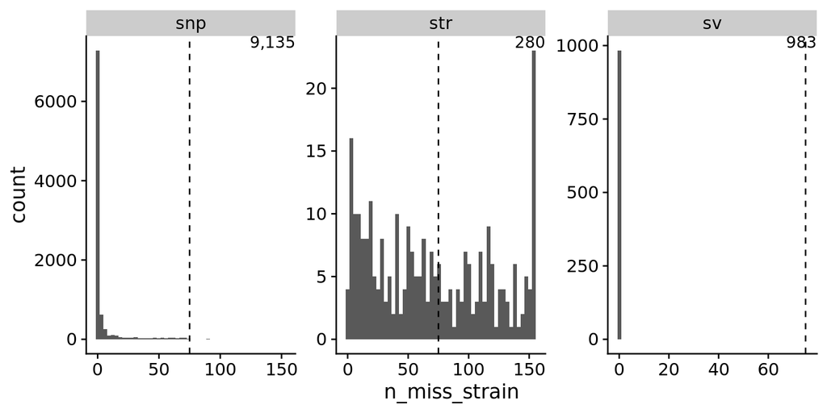

```r
    p = n_miss_per_loc %>%
        ggplot(aes(n_miss_strain)) +
        geom_histogram(bins = 50) +
        geom_vline(xintercept = 75, linetype = 'dashed') +
        geom_text(data = ~.x %>% count(loc_type),
              aes(label = scales::comma(n)), x = Inf, y = Inf, hjust = 'inward', vjust = 'inward') +
        facet_wrap(~loc_type, scales = 'free') +
        theme_half_open()
    p
```

```r
    ggsave('test.pdf', p, w = 8, h = 4)

    # filter loci with too many missing strains
    loci_gts = loci_gts %>%
        # anti_join(n_miss_per_loc %>% filter(n_miss_strain >= 75), by = c('loc_type', 'chr', 'pos', 'end'))
        anti_join(n_miss_per_loc %>% filter(n_miss_strain >= 75), by = c('loc_type', 'loc_id'))

    # apply filter to reduced annotated variants
    redux_vep_annot = redux_vep_annot %>% semi_join(loci_gts, by = 'loc_id')
```

# 22 Updated annotated variant counts

```r
    redux_vep_annot %>%
        distinct(loc_type, loc_id) %>%
        count(loc_type, name = 'n_loci')
```

| loc_type | n_loci |
| --- | --- |
| snp | 9103 |
| str | 160 |
| sv | 983 |

# 23 Other locus properties

## 23.1 Number of genotypes per locus

1. Three alleles makes sense because of het loci

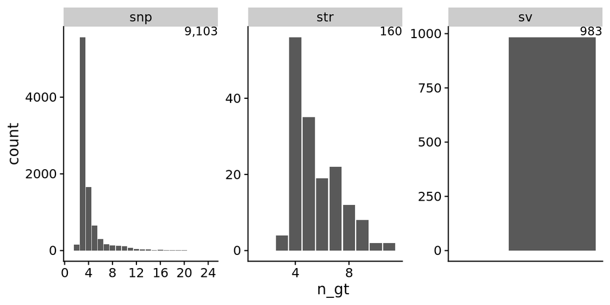

```r
    # check on multi-allelic variants
    ngt_per_loc = loci_gts %>%
        # distinct(loc_type, chr, pos, end, gt) %>%
        distinct(loc_type, loc_id, gt) %>%
        # count(loc_type, chr, pos, end, name = 'n_gt')
        count(loc_type, loc_id, name = 'n_gt')
        # ngt_per_loc %>% count(n_gt)

    p = ngt_per_loc %>%
        ggplot(aes(n_gt)) +
        geom_bar(stat = 'count') +
        geom_text(data = ~.x %>% count(loc_type),
              aes(label = scales::comma(n)), x = Inf, y = Inf, hjust = 'inward', vjust = 'inward') +
        scale_x_continuous(breaks = scales::breaks_width(width = 4)) +
        coord_cartesian(xlim = c(1, NA)) +
        facet_wrap(~loc_type, scales = 'free') +
        theme_half_open()
    p
```

```r
    ggsave('test.pdf', p, w = 8, h = 4)
```

## 23.2 Non-major allele frequency

1. Filters: `filter1 & filter2`

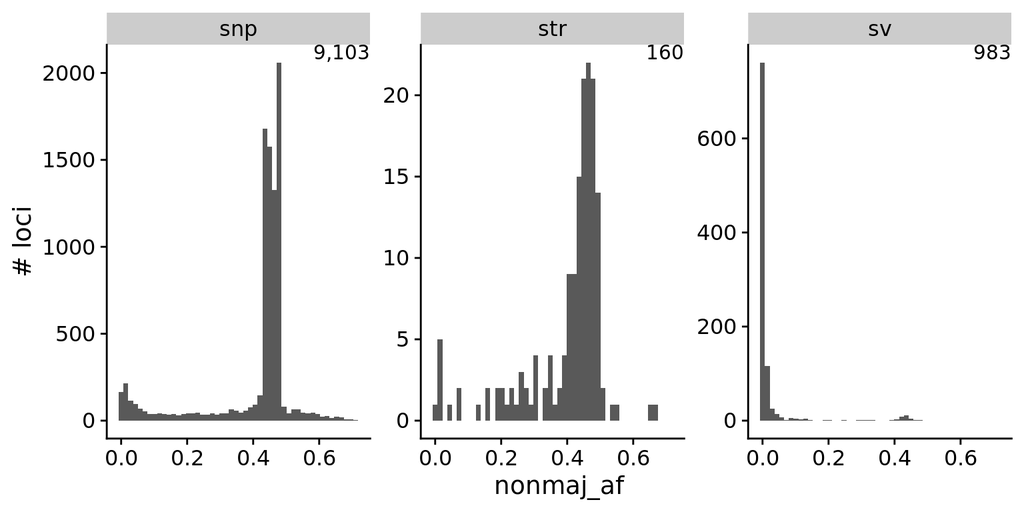

```r
    # calculate allele frequence and distplay non-major allele count
    al_freq = loci_gts %>%
        filter(!is.na(GT_A)) %>%
        pivot_longer(cols = c(GT_A, GT_B), names_to = 'al_type', values_to = 'al') %>%
        # count(loc_type, chr, pos, end, al) %>%
        count(loc_type, loc_id, al) %>%
        # group_by(loc_type, chr, pos, end) %>%
        group_by(loc_type, loc_id) %>%
        mutate(tot_ac = sum(n), freq = n/sum(n)) %>%
        ungroup %>%
        arrange(desc(n)) %>%
        # distinct(loc_type, chr, pos, end, .keep_all = TRUE) %>%
        distinct(loc_type, loc_id, .keep_all = TRUE) %>%
        rename(maj_af = freq) %>%
        mutate(nonmaj_af = 1 - maj_af) %>%
        # select(loc_type, chr, pos, end, tot_ac, maj_af, nonmaj_af)
        select(loc_type, loc_id, tot_ac, maj_af, nonmaj_af)

    p = al_freq %>%
        ggplot(aes(nonmaj_af)) +
        geom_histogram(bins = 50) +
        # geom_text(data = ~.x %>% distinct(loc_type, chr, pos, end) %>% count(loc_type),
        geom_text(data = ~.x %>% distinct(loc_type, loc_id) %>% count(loc_type),
              aes(label = scales::comma(n)), x = Inf, y = Inf, hjust = 'inward', vjust = 'inward') +
        facet_wrap(~loc_type, scales = 'free_y') +
        theme_half_open() +
        labs(y = '# loci')
    p
```

```r
    ggsave('test.pdf', p, w = 8, h = 4)
```

# 24 Load %expanded phenotype

```r
    in_cache_dir = '../data/analysis_cache/bxd_qtl_scans'
    pheno_vals = readRDS(path(in_cache_dir, 'final_qtl.rds'))$pheno_vals %>%
        # distinct(metric) %>%
        filter(metric == 'proportion_expanded')
```

# 25 Regress phenotype on genotype for each locus

1. Simple ANOVA with genotype as factor

```r
    cache_dir = '../data/analysis_cache/annot'; dir_create(cache_dir)
    cache_file = path(cache_dir, 'vep_loci_fits.rds'); redo = FALSE
    if (!file_exists(cache_file) | redo) {
        # standard lm way
        if (1) {
            nested_loci_gts = loci_gts %>%
                filter(!is.na(GT_A)) %>%
                mutate(GT_T = GT_A + GT_B) %>%
                left_join(pheno_vals %>% select(strain, pheno), by = 'strain') %>%
                # nest(data = !c(loc_type, chr, pos, end))
                nest(data = !c(loc_type, loc_id))
            # get some test data
            # locus_data = nested_loci_gts %>%
            #     filter(loc_type == 'snp') %>%
            #     slice_sample(n = 1) %>% pull(data) %>% .[[1]]
            # locus_data = nested_loci_gts %>% filter(pos == 88825954) %>% pull(data) %>% .[[1]]
            fit_lm = function(locus_data, type = c('linear', 'aov')) {
                if (type == 'linear') {
                    lm(pheno ~ GT_T, data = locus_data) %>% broom::tidy() %>%
                    filter(term == 'GT_T') %>% select(p.value)
                } else if (type == 'aov') {
                    anova(lm(pheno ~ gt, data = locus_data)) %>%
                    broom::tidy() %>% filter(term == 'gt') %>% select(p.value)
                }
            }
            # fit_lm(locus_data, 'linear')
            # fit_lm(locus_data, 'aov')

            # run for all loci
            # pb <- progress_bar$new(total = loci_gts %>% distinct(loc_type, chr, pos, end) %>% nrow)
            pb <- progress_bar$new(total = loci_gts %>% distinct(loc_type, loc_id) %>% nrow)
            assoc_test = nested_loci_gts %>%
                mutate(lm_fit = map2(data, loc_id, function(.x, .y) {
                    pb$tick()
                    ret = try(fit_lm(.x, 'aov'), silent = TRUE)
                    if (class(ret) != 'try-error') {
                        return(ret)
                    } else { return(tibble(p.value = NA)) }
                })) %>% select(!data) %>% unnest(lm_fit)
        } else {
            ## with GEMMA

            # phenotype matrix
            pheno = pheno_vals %>% select(strain, pheno)
            strain_ord = pheno %>% pull(strain)

            # genotype matrix
            geno = loci_gts %>%
                filter(!is.na(GT_A)) %>%
                mutate(GT_T = GT_A + GT_B) %>%
                # pivot_wider(id_cols = c(loc_type, chr, pos, end), names_from = strain, values_from = GT_T) %>%
                pivot_wider(id_cols = c(loc_type, loc_id), names_from = strain, values_from = GT_T) %>%
                unite('locus', c('loc_type', 'chr', 'pos', 'end'))
            geno = geno %>% select(locus, all_of(strain_ord))
            geno = geno %>% mutate(al_A = 'X', al_B = 'Y') %>% relocate(c(al_A, al_B), .after = 1)

            # kinship
            grm = calc_kinship(BXDstrs::qtl_data$snp_probs, type = 'overall')
            grm = grm[strain_ord, strain_ord] %>%
                as.data.frame %>%
                rownames_to_column(var = 'strain') %>%
                as_tibble

            # covariates
            covar = BXDstrs::strain_info %>%
                select(bxd_id, gen_inbreeding) %>%
                mutate(intercept = 1) %>%
                select(strain = bxd_id, intercept, gen_inbreeding) %>%
                mutate(strain = fct_relevel(strain, strain_ord)) %>%
                arrange(strain) %>%
                mutate(strain = as.character(strain))

            # run GEMMA
            tmp_dir = 'tmp'
            dir_create(tmp_dir)
            assoc_test = BXDstrs::run_gemma(
                geno, pheno, covar, grm, strain_ord, covar_cols = 'gen_inbreeding',
                gemma_exec = '/home/momaksimov/bin/gemma-0.98.1-linux-static',
                gemma_options = '-n 1 -notsnp -lmm 4 -r2 1 -miss 1',
                tmp_dir = 'tmp', tmp_file = 'gemma')
            dir_delete(tmp_dir)

            # format results
            assoc_test = assoc_test %>%
                separate('rs', c('loc_type', 'chr', 'pos', 'end')) %>%
                # select(loc_type, chr, pos, end, estimate = beta, std.error = se, p.value = p_wald) %>%
                select(loc_type, loc_id, estimate = beta, std.error = se, p.value = p_wald) %>%
                mutate(across(c(pos, end), as.integer))
        }

        # save cache
        saveRDS(assoc_test, cache_file)
    } else {
        assoc_test = readRDS(cache_file)
    }

    # check if association was run for all loci
    if (!all_equal(
        # loci_gts %>% distinct(loc_type, chr, pos, end),
        # assoc_test %>% distinct(loc_type, chr, pos, end)
        loci_gts %>% distinct(loc_type, loc_id),
        assoc_test %>% distinct(loc_type, loc_id)
        )) stop('Association tests missing')

    # join allele frequency information; discard intercept
    assoc_test = assoc_test %>%
        filter(!is.na(p.value)) %>%
        # filter(term == 'GT_T') %>%
        # left_join(al_freq, by = c('loc_type', 'chr', 'pos', 'end'))
        left_join(al_freq, by = c('loc_type', 'loc_id'))
```

# 26 Simplify using top consequence

1. VEP assigns to a variant/feature pair
   - One or more IMPACTs
   - One or more Consequences
   - Consequence field can be a concatenation of multiple SO terms
2. This creates a large amount of row redundancy

FOR PLOTTING

1. Want a single datapoint per variant/gene
   - Use most severe consequence instead of concatenate Consequence column
   - For every variant/gene/Feature/IMPACT, keep the most severe consequence
   - For every variant/gene/Feature, keep the most severe IMPACT
   - For every variant/gene, keep the Feature with the most severe IMPACT

FOR TABULAR DISPLAY

1. Want a single row per variant/gene/IMPACT and multi-level information concatenated
   - For every variant/gene/Feature/IMPACT, keep the Consequence with the most severe top consequence (otherwise too complicated)
   - For every variant/gene/IMPACT concatenate all Features where the IMPACT happens and level concatenate the Consequence columns (i.e. lvl1/lvl1/lvl1, lvl2/lvl2, lvl3)

```r
    # read in severity of VEP consequences
    vep_conseq = readr::read_delim('../info/vep_conseq.csv', delim = ';', col_types = cols(.default = 'c')) %>%
        # group_by(IMPACT) %>%
        mutate(severity = 1:n())

    # notes on VEP data
    if (0) {
        # IMPACT and Consequence assigned to every variant Feature pair (in our case feature is either Transcript or RegulatoryFeature)
        redux_vep_annot %>% distinct(Feature_type)
        # Feature_type
        # <chr>
        # Transcript
        # RegulatoryFeature

        # Trascripts and RegulatoryFeatures are associated with SYMBOLs: 1 gene per Transcripts BUT rarely multiple genes associated with RegulatoryFeature
        redux_vep_annot %>% distinct(SYMBOL, Feature) %>% count(Feature, name = 'n_gene') %>% count(n_gene)
        # n_gene     n
        #      1  1078
        #      2     6
        redux_vep_annot %>% distinct(SYMBOL, Feature) %>% filter(Feature %in% Feature[duplicated(Feature)])

        # mostly variants have a single impact on a particular Transcript and always a single impact on a particular RegulatoryFeature
        # rarely a single variant can have multiple IMAPCTs on a single Transcript
        redux_vep_annot %>%
            distinct(loc_type, chr, pos, end, Feature_type, Feature, IMPACT) %>%
            count(loc_type, chr, pos, end, Feature_type, Feature, name = 'n_impact') %>%
            # filter(n_impact > 1) %>%
            count(Feature_type, n_impact)
        # Feature_type      n_impact      n
        # RegulatoryFeature        1  17410
        # Transcript               1 265794
        # Transcript               2     76
        redux_vep_annot %>% filter(Feature == 'ENSMUST00000109546', pos == 89690081)

        # again most of the time, a single Consequence will be assigned to a variant having a particular impact in a Feature, but rarely multiple
        redux_vep_annot %>%
            filter(Feature_type == c('Transcript', 'RegulatoryFeature')[1]) %>%
            distinct(loc_type, chr, pos, end, Feature, IMPACT, Consequence) %>%
            count(loc_type, chr, pos, end, Feature, IMPACT, name = 'n_conseq') %>%
            # filter(n_conseq > 1)
            count(n_conseq)
        # n_conseq      n
        #    <int>  <int>
        #        1 265911
        #        2     30
        #        3      5
        vep_annot %>% filter(Feature == 'ENSMUST00000022220', IMPACT == 'HIGH', pos == 92263797)

        # consequences are comman separate concatenation (first one is the most severe) - special care needed to reduce these
        redux_vep_annot %>% distinct(Consequence)
        # Consequence
        # intron_variant
        # intron_variant,non_coding_transcript_variant
        # regulatory_region_variant
        # non_coding_transcript_exon_variant
        # downstream_gene_variant

        # split consequences that have been comma-concatenated
        conseq_split = vep_annot %>%
            distinct(IMPACT, Consequence) %>%
            mutate(conseq_split = map(Consequence, function(.x) {
            csq = str_split(.x, ',')[[1]]
            tibble(ord = 1:length(csq), csq)
            })) %>%
            unnest(conseq_split)

        # "Consequence" field may be a concatenation of multiple vep SO terms
        # check that these are ordered in direction of decreasing severity
        conseq_split %>%
            # keep only merged ones with multiple csq concatenated into Consequence
            filter(Consequence != csq) %>%
            left_join(vep_conseq %>% select(SO_term, severity), by = c('csq' = 'SO_term')) %>%
            group_by(Consequence) %>%
            summarise(is_increasing = all(diff(severity) > 0), .groups = 'drop') %>%
            count(is_increasing)
    }

    # find top consequence for each comma separate Consequence
    conseq_split = vep_annot %>%
        distinct(IMPACT, Consequence) %>%
        mutate(conseq_split = map(Consequence, function(.x) {
            csq = str_split(.x, ',')[[1]]
            tibble(ord = 1:length(csq), csq)
        })) %>%
        unnest(conseq_split) %>%
        group_by(Consequence) %>%
        slice_min(n = 1, order_by = ord, with_ties = FALSE) %>%
        ungroup %>%
        left_join(vep_conseq %>% select(SO_term, severity), by = c('csq' = 'SO_term'))
        conseq_split = conseq_split %>% distinct(Consequence, csq, severity) %>% rename(top_csq = csq)

    # function for splitting Consequence column, then reconcatenating
    # comma_sep_vals = c("synonymous_variant", "synonymous_variant", "non_coding_transcript_exon_variant", "downstream_gene_variant", "non_coding_transcript_exon_variant", "upstream_gene_variant", "synonymous_variant,NMD_transcript_variant", "3_prime_UTR_variant,NMD_transcript_variant", "3_prime_UTR_variant,NMD_transcript_variant")
    lvl_concat = function(comma_sep_vals) {
        val_mat = comma_sep_vals %>% str_split(',', simplify = TRUE)
        apply(val_mat, 2, function(.x) str_c(.x %>% discard(~.x == '') %>% unique, collapse = '/')) %>% unique %>% str_c(collapse = ',')
    }
    # lvl_concat(comma_sep_vals)
    # lvl_concat(c("synonymous_variant", "synonymous_variant"))
    # lvl_concat(c("synonymous_variant", "non_coding_transcript_exon_variant"))

    # make a data.frame for tabular display
    redux_vep_annot_tab_disp = redux_vep_annot %>%
        left_join(conseq_split, by = 'Consequence') %>%
        arrange(severity) %>%
        # distinct(loc_type, chr, pos, end, SYMBOL, Feature, IMPACT, .keep_all = TRUE) %>%
        # group_by(loc_type, chr, pos, end, SYMBOL, IMPACT) %>%
        distinct(loc_type, loc_id, SYMBOL, Feature, IMPACT, .keep_all = TRUE) %>%
        group_by(loc_type, loc_id, SYMBOL, IMPACT) %>%
        summarise(Consequence = lvl_concat(Consequence),
              Feature = str_c(Feature %>% unique, collapse = ','),
              BIOTYPE = str_c(BIOTYPE %>% unique, collapse = ','),
              Feature_type = str_c(Feature_type %>% unique, collapse = ','), .groups = 'drop'
        )

    # create a function for reducing for plotting data
    # NOTE: this function not used in this script, but saving for continuity
    # reduce_for_plt = function(data) {
    #   data %>%
    #       left_join(conseq_split, by = 'Consequence') %>%
    #       arrange(severity) %>%
    #       # distinct(loc_type, chr, pos, end, SYMBOL, Feature, IMPACT, .keep_all = TRUE) %>%
    #       distinct(loc_type, loc_id, SYMBOL, Feature, IMPACT, .keep_all = TRUE) %>%
    #       arrange(IMPACT) %>%
    #       # distinct(loc_type, chr, pos, end, SYMBOL, Feature, .keep_all = TRUE) %>%
    #       # distinct(loc_type, chr, pos, end, SYMBOL, .keep_all = TRUE)
    #       distinct(loc_type, loc_id, SYMBOL, Feature, .keep_all = TRUE) %>%
    #       distinct(loc_type, loc_id, SYMBOL, .keep_all = TRUE)
    # }
```

# 27 Export data

```r
    # vep annot contains useful data we may want for downstream analysis like rsids for example
    raw_vep_annot = raw_vep_annot %>%
        mutate(loc_id = if_else(loc_type %in% c('str', 'snp'),
                                str_c(chr, '_', pos, '_', end),
                                str_c(chr, '_', pos, '_', end, '_', sv_type))) %>%
        semi_join(redux_vep_annot, by = 'loc_id')

    vep_data = list(
        tx_info                  = tx_info,
        assoc_test               = assoc_test,
        conseq_split             = conseq_split,
        loci_gts                 = loci_gts,
        al_freq                  = al_freq,
        redux_vep_annot          = redux_vep_annot,
        redux_vep_annot_tab_disp = redux_vep_annot_tab_disp,
        raw_vep_annot            = raw_vep_annot
    )
    saveRDS(vep_data, path(cache_dir, 'vep_data.rds'))
```